# examples_0415

On the right triangle below, find the length of the missing side.

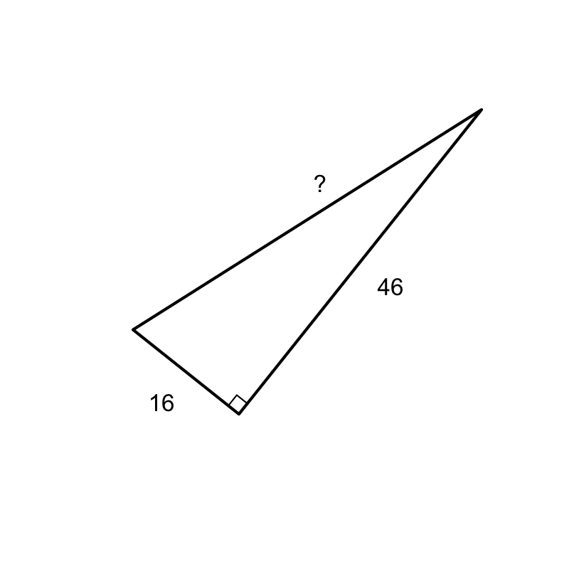

The tolerance is $\pm 0.1$.

Use pythagorean theorem.

$$a=46$$
$$b=16$$

$a^2+b^2=c^2$

$$c = \sqrt{a^2+b^2}$$

$$c = \sqrt{{46}^2+{16}^2}$$

$$c\approx 48.70$$

On the right triangle below, find the length of the missing side.

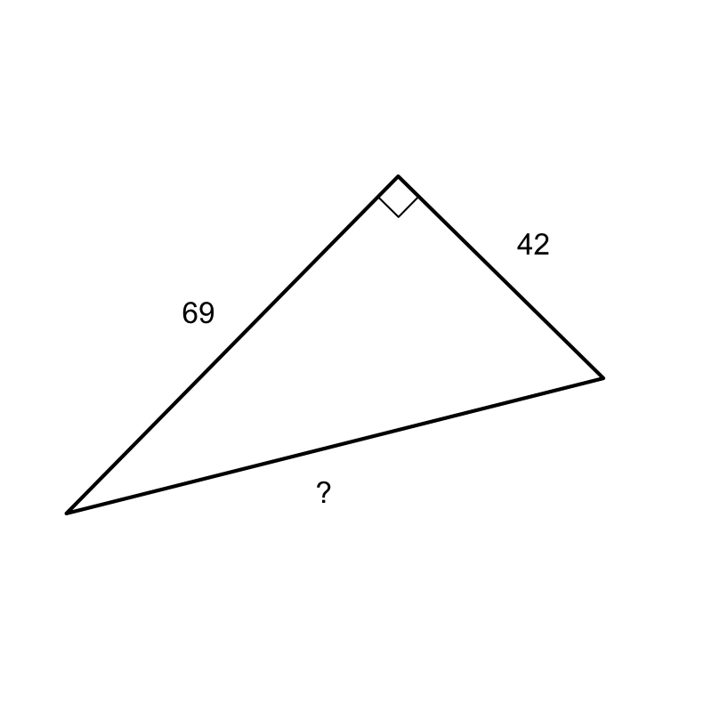

The tolerance is $\pm 0.1$.

Use pythagorean theorem.

$$a=42$$
$$b=69$$

$a^2+b^2=c^2$

$$c = \sqrt{a^2+b^2}$$

$$c = \sqrt{{42}^2+{69}^2}$$

$$c\approx 80.78$$

On the right triangle below, find the length of the missing side.

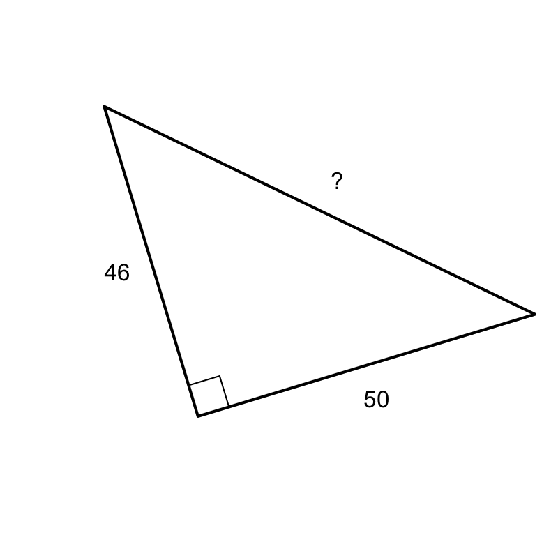

The tolerance is $\pm 0.1$.

Use pythagorean theorem.

$$a=46$$
$$b=50$$

$a^2+b^2=c^2$

$$c = \sqrt{a^2+b^2}$$

$$c = \sqrt{{46}^2+{50}^2}$$

$$c\approx 67.94$$

On the right triangle below, find the length of the missing side.

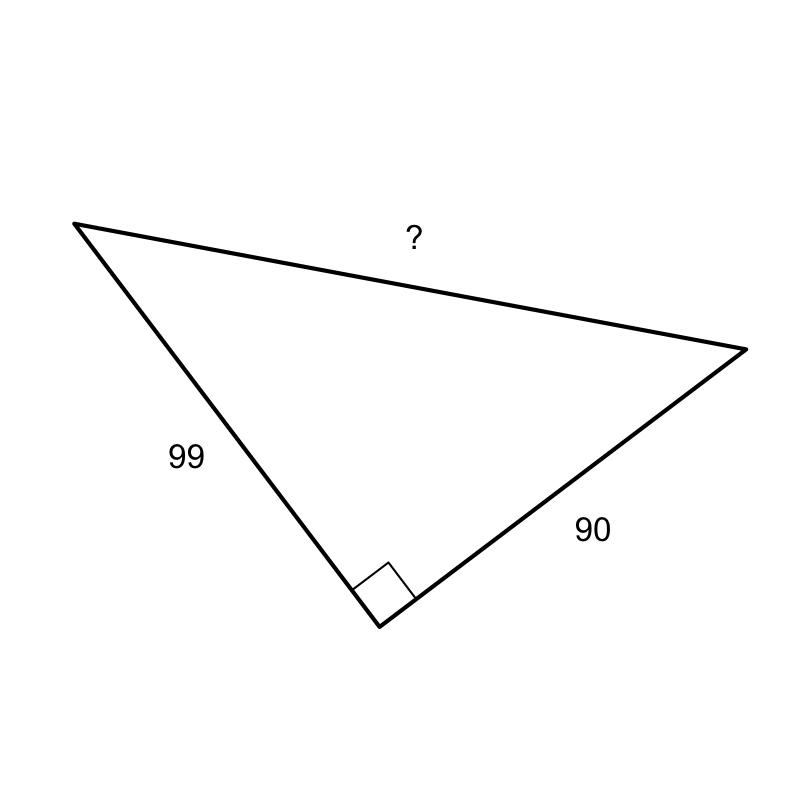

The tolerance is $\pm 0.1$.

Use pythagorean theorem.

$$a=90$$
$$b=99$$

$a^2+b^2=c^2$

$$c = \sqrt{a^2+b^2}$$

$$c = \sqrt{{90}^2+{99}^2}$$

$$c\approx 133.79$$

On the right triangle below, find the length of the missing side.

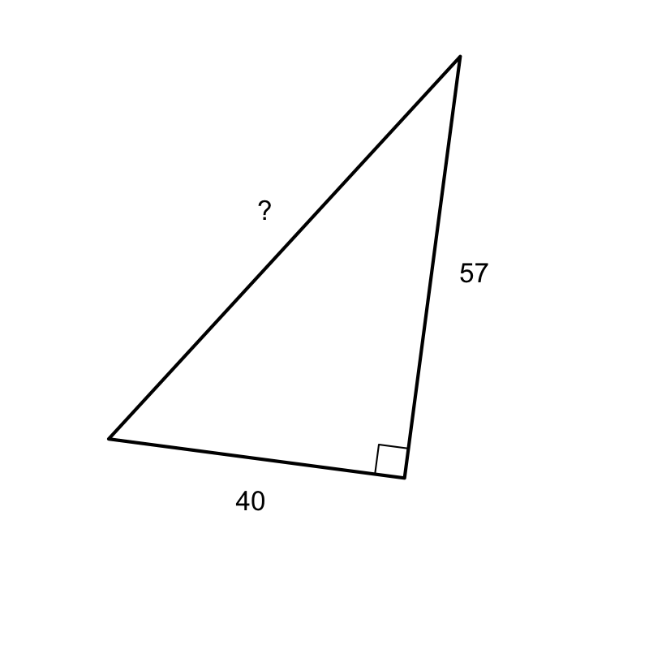

The tolerance is $\pm 0.1$.

Use pythagorean theorem.

$$a=57$$
$$b=40$$

$a^2+b^2=c^2$

$$c = \sqrt{a^2+b^2}$$

$$c = \sqrt{{57}^2+{40}^2}$$

$$c\approx 69.63$$

On the right triangle below, find the length of the missing side.

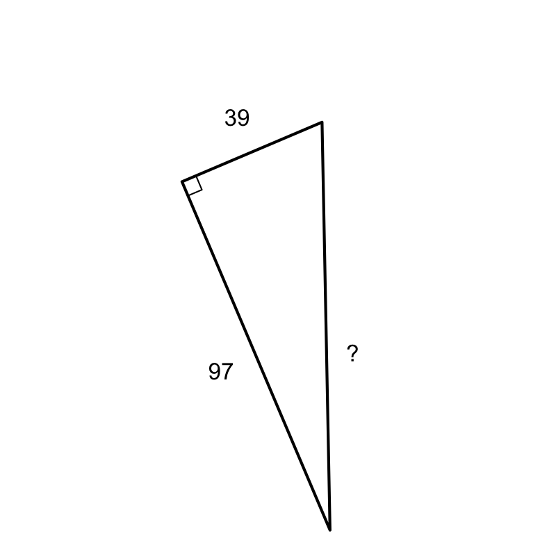

The tolerance is $\pm 0.1$.

Use pythagorean theorem.

$$a=97$$
$$b=39$$

$a^2+b^2=c^2$

$$c = \sqrt{a^2+b^2}$$

$$c = \sqrt{{97}^2+{39}^2}$$

$$c\approx 104.55$$

On the right triangle below, find the length of the missing side.

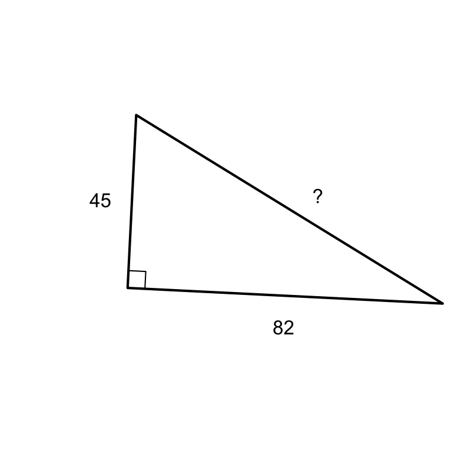

The tolerance is $\pm 0.1$.

Use pythagorean theorem.

$$a=82$$
$$b=45$$

$a^2+b^2=c^2$

$$c = \sqrt{a^2+b^2}$$

$$c = \sqrt{{82}^2+{45}^2}$$

$$c\approx 93.54$$

On the right triangle below, find the length of the missing side.

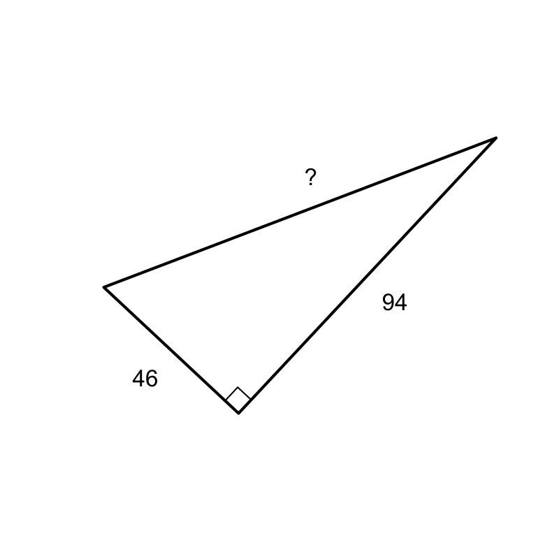

The tolerance is $\pm 0.1$.

Use pythagorean theorem.

$$a=46$$
$$b=94$$

$a^2+b^2=c^2$

$$c = \sqrt{a^2+b^2}$$

$$c = \sqrt{{46}^2+{94}^2}$$

$$c\approx 104.65$$

On the right triangle below, find the length of the missing side.

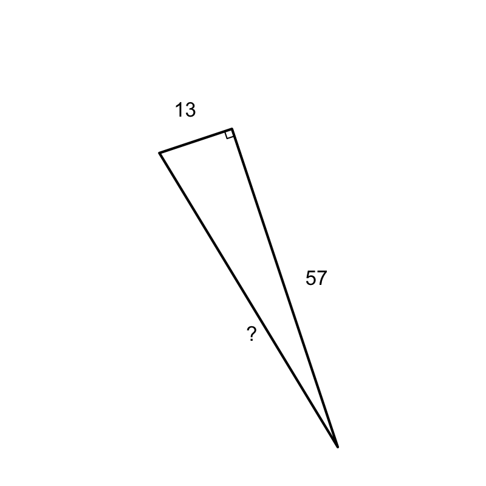

The tolerance is $\pm 0.1$.

Use pythagorean theorem.

$$a=57$$
$$b=13$$

$a^2+b^2=c^2$

$$c = \sqrt{a^2+b^2}$$

$$c = \sqrt{{57}^2+{13}^2}$$

$$c\approx 58.46$$

On the right triangle below, find the length of the missing side.

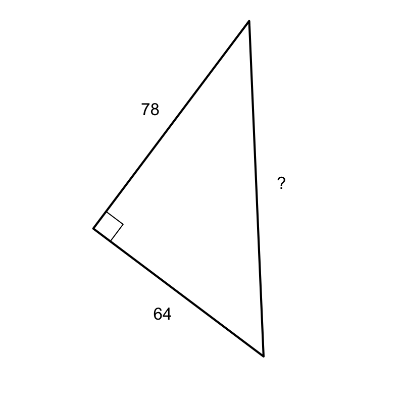

The tolerance is $\pm 0.1$.

Use pythagorean theorem.

$$a=64$$
$$b=78$$

$a^2+b^2=c^2$

$$c = \sqrt{a^2+b^2}$$

$$c = \sqrt{{64}^2+{78}^2}$$

$$c\approx 100.90$$

On the right triangle below, find the length of the missing side.

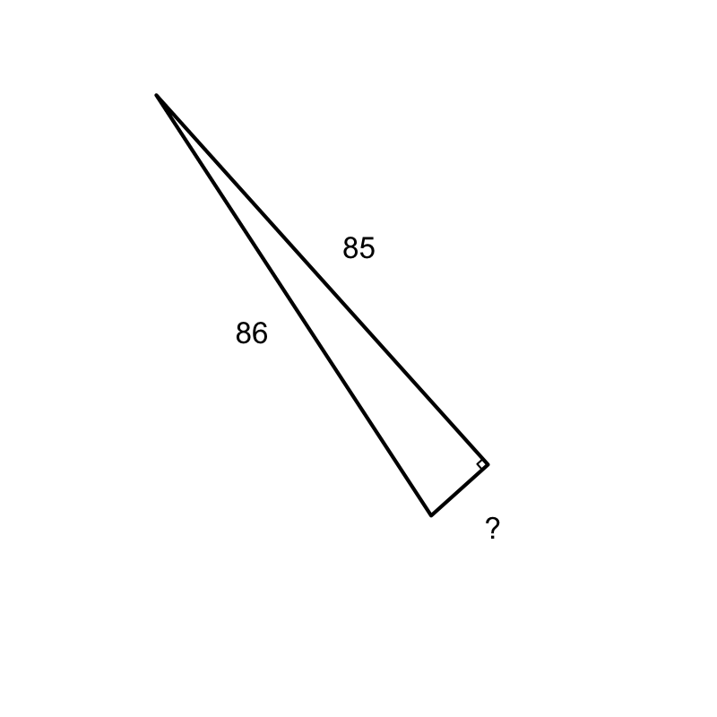

The tolerance is $\pm 0.1$.

Use pythagorean theorem.

$$a=85$$
$$c=86$$

$a^2+b^2=c^2$

$b^2=c^2-a^2$

$$b = \sqrt{c^2-a^2}$$

$$b = \sqrt{{86}^2-{85}^2}$$

$$b\approx 13.08$$

On the right triangle below, find the length of the missing side.

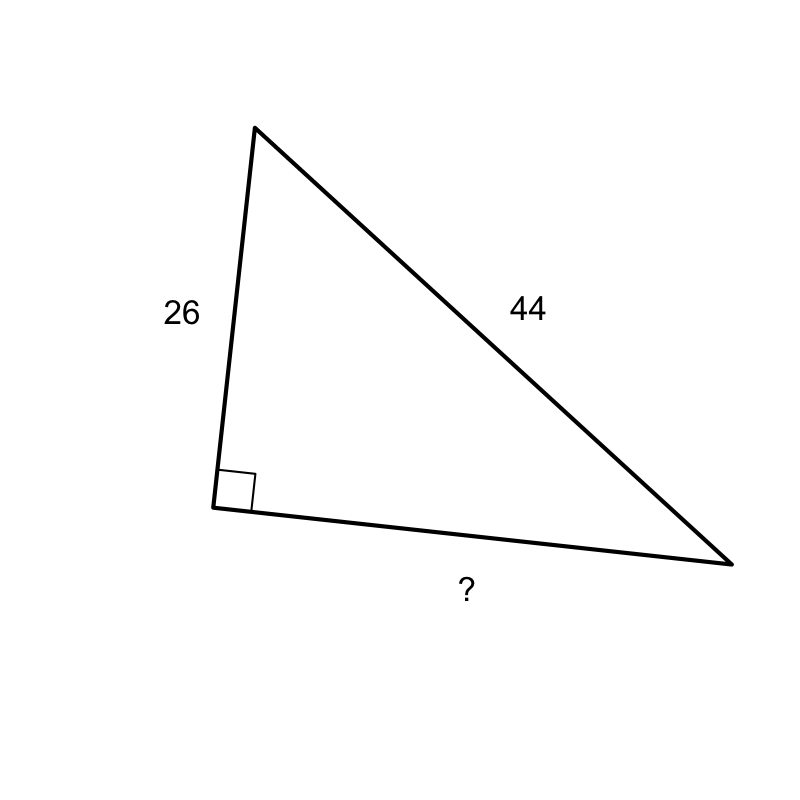

The tolerance is $\pm 0.1$.

Use pythagorean theorem.

$$a=26$$
$$c=44$$

$a^2+b^2=c^2$

$b^2=c^2-a^2$

$$b = \sqrt{c^2-a^2}$$

$$b = \sqrt{{44}^2-{26}^2}$$

$$b\approx 35.50$$

On the right triangle below, find the length of the missing side.

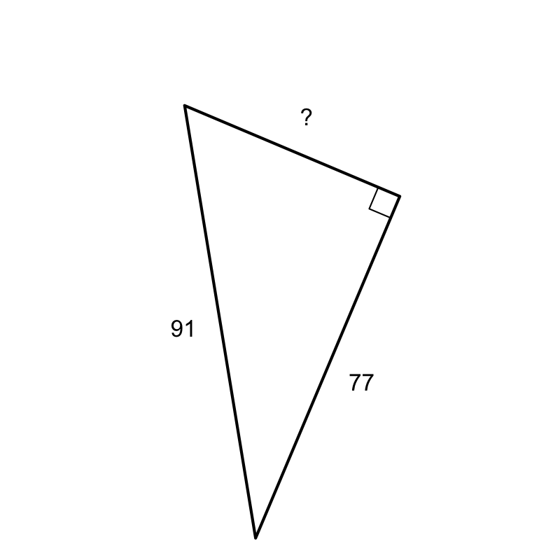

The tolerance is $\pm 0.1$.

Use pythagorean theorem.

$$a=77$$
$$c=91$$

$a^2+b^2=c^2$

$b^2=c^2-a^2$

$$b = \sqrt{c^2-a^2}$$

$$b = \sqrt{{91}^2-{77}^2}$$

$$b\approx 48.50$$

On the right triangle below, find the length of the missing side.

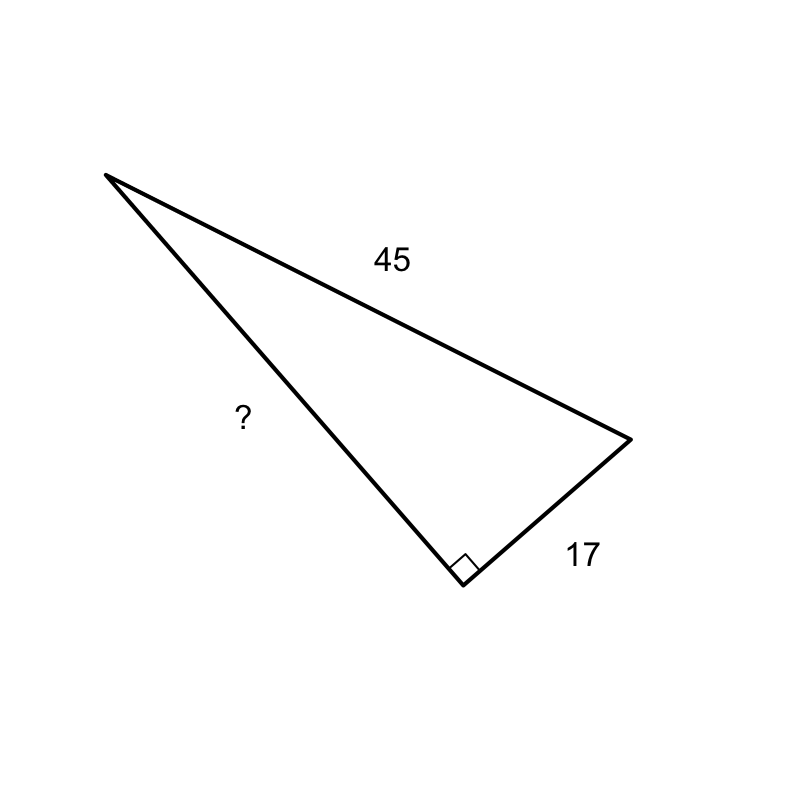

The tolerance is $\pm 0.1$.

Use pythagorean theorem.

$$a=17$$
$$c=45$$

$a^2+b^2=c^2$

$b^2=c^2-a^2$

$$b = \sqrt{c^2-a^2}$$

$$b = \sqrt{{45}^2-{17}^2}$$

$$b\approx 41.67$$

On the right triangle below, find the length of the missing side.

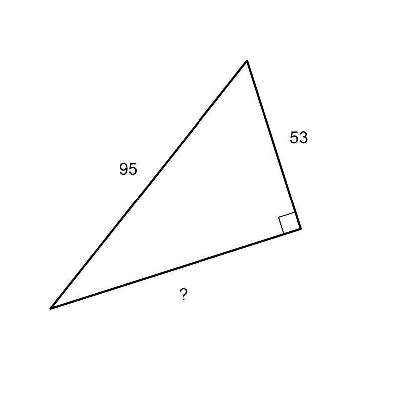

The tolerance is $\pm 0.1$.

Use pythagorean theorem.

$$a=53$$
$$c=95$$

$a^2+b^2=c^2$

$b^2=c^2-a^2$

$$b = \sqrt{c^2-a^2}$$

$$b = \sqrt{{95}^2-{53}^2}$$

$$b\approx 78.84$$

On the right triangle below, find the length of the missing side.

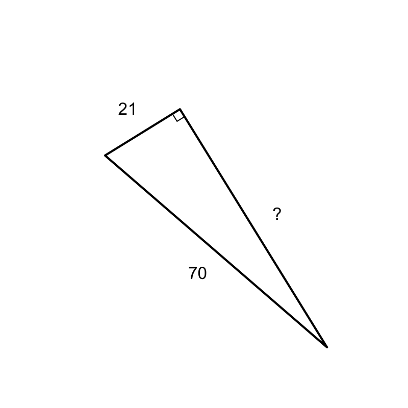

The tolerance is $\pm 0.1$.

Use pythagorean theorem.

$$a=21$$
$$c=70$$

$a^2+b^2=c^2$

$b^2=c^2-a^2$

$$b = \sqrt{c^2-a^2}$$

$$b = \sqrt{{70}^2-{21}^2}$$

$$b\approx 66.78$$

On the right triangle below, find the length of the missing side.

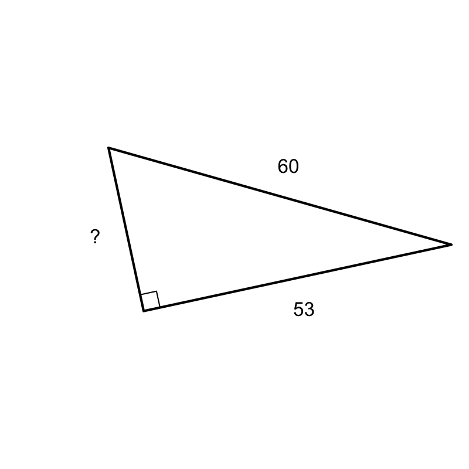

The tolerance is $\pm 0.1$.

Use pythagorean theorem.

$$a=53$$
$$c=60$$

$a^2+b^2=c^2$

$b^2=c^2-a^2$

$$b = \sqrt{c^2-a^2}$$

$$b = \sqrt{{60}^2-{53}^2}$$

$$b\approx 28.12$$

On the right triangle below, find the length of the missing side.

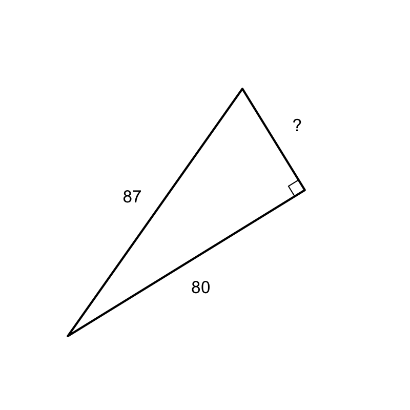

The tolerance is $\pm 0.1$.

Use pythagorean theorem.

$$a=80$$
$$c=87$$

$a^2+b^2=c^2$

$b^2=c^2-a^2$

$$b = \sqrt{c^2-a^2}$$

$$b = \sqrt{{87}^2-{80}^2}$$

$$b\approx 34.19$$

On the right triangle below, find the length of the missing side.

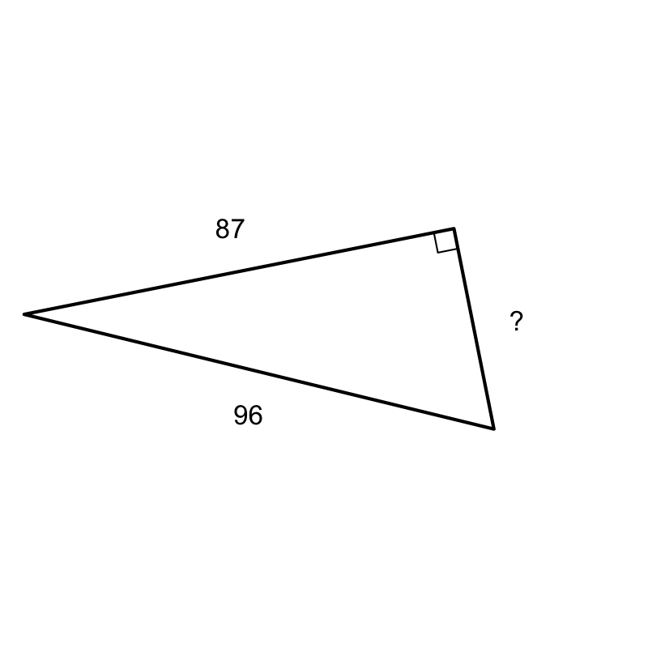

The tolerance is $\pm 0.1$.

Use pythagorean theorem.

$$a=87$$
$$c=96$$

$a^2+b^2=c^2$

$b^2=c^2-a^2$

$$b = \sqrt{c^2-a^2}$$

$$b = \sqrt{{96}^2-{87}^2}$$

$$b\approx 40.58$$

On the right triangle below, find the length of the missing side.

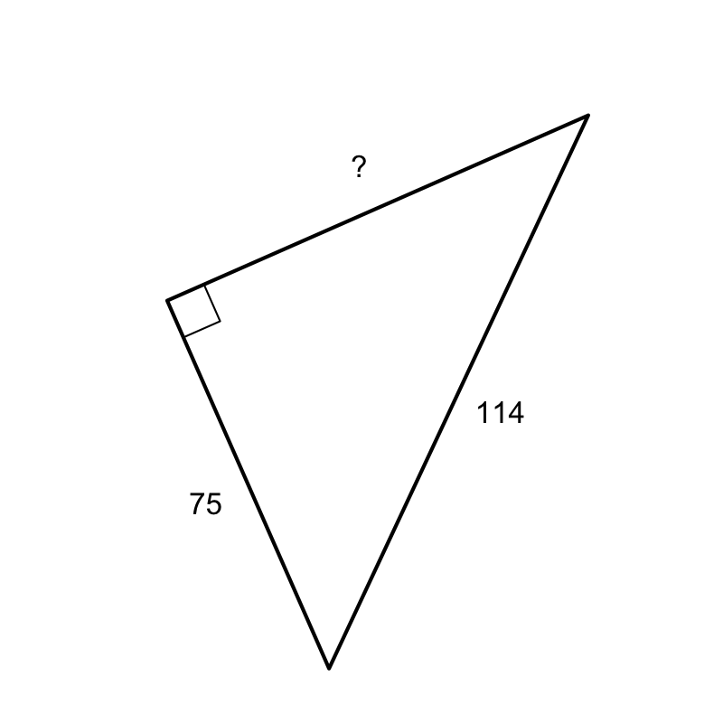

The tolerance is $\pm 0.1$.

Use pythagorean theorem.

$$a=75$$
$$c=114$$

$a^2+b^2=c^2$

$b^2=c^2-a^2$

$$b = \sqrt{c^2-a^2}$$

$$b = \sqrt{{114}^2-{75}^2}$$

$$b\approx 85.85$$

A triangle has vertices at $(0,0)$ and $(6,0)$ and $(1,5)$. Find the area (in square units).

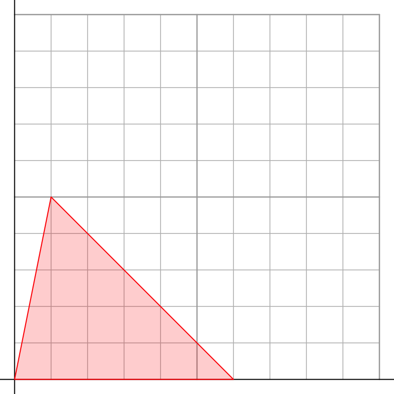

The area of a triangle is half the base times the height.

$$A=\frac{6\cdot 5}{2}$$

You should be able to see it is half the area of the surrounding rectangle...

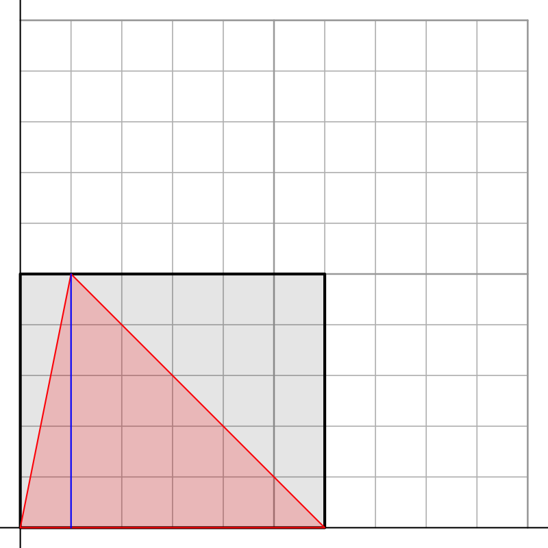

A triangle has vertices at $(0,0)$ and $(6,0)$ and $(3,5)$. Find the area (in square units).

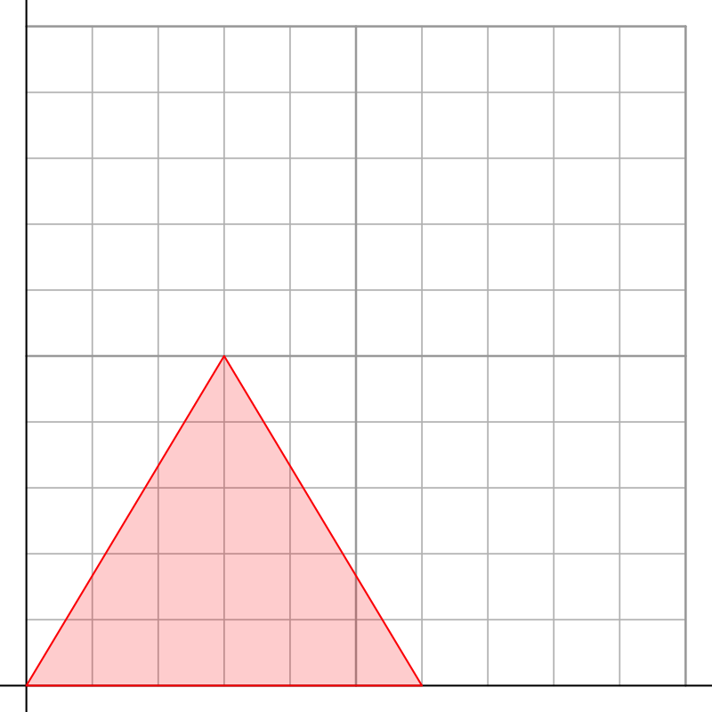

The area of a triangle is half the base times the height.

$$A=\frac{6\cdot 5}{2}$$

You should be able to see it is half the area of the surrounding rectangle...

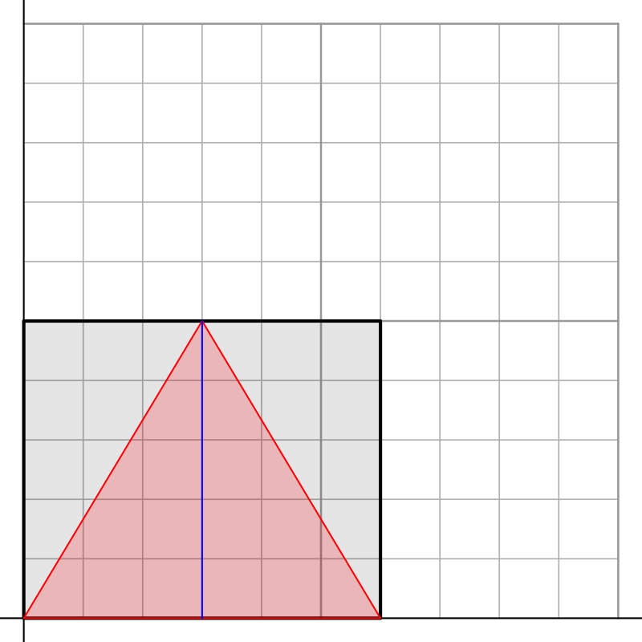

A triangle has vertices at $(0,0)$ and $(5,0)$ and $(2,5)$. Find the area (in square units).

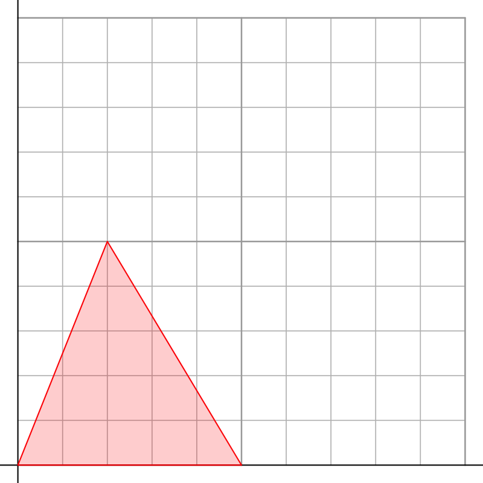

The area of a triangle is half the base times the height.

$$A=\frac{5\cdot 5}{2}$$

You should be able to see it is half the area of the surrounding rectangle...

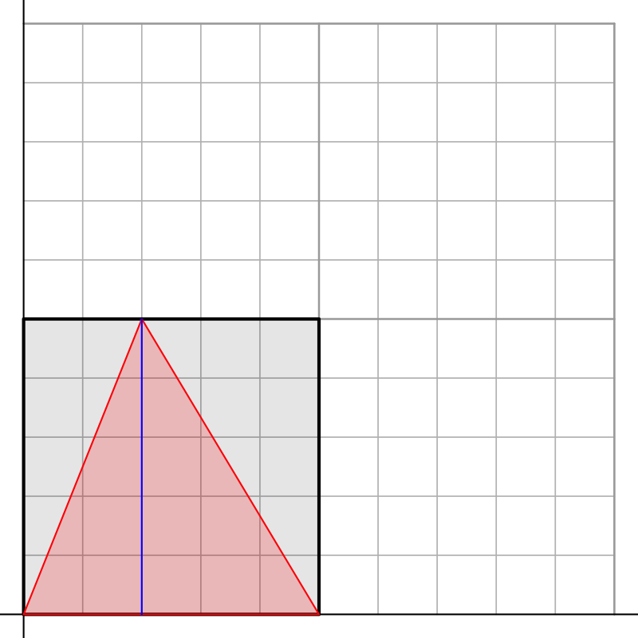

A triangle has vertices at $(0,0)$ and $(6,0)$ and $(2,4)$. Find the area (in square units).

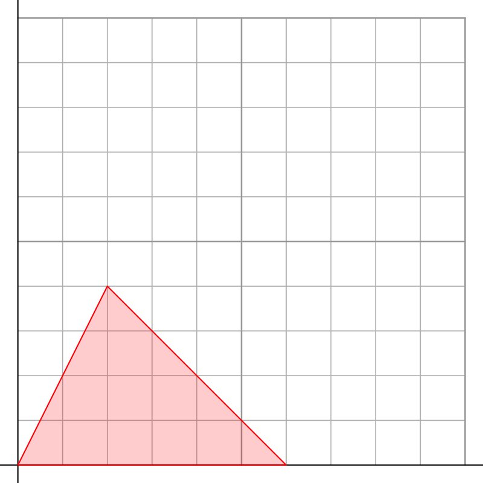

The area of a triangle is half the base times the height.

$$A=\frac{6\cdot 4}{2}$$

You should be able to see it is half the area of the surrounding rectangle...

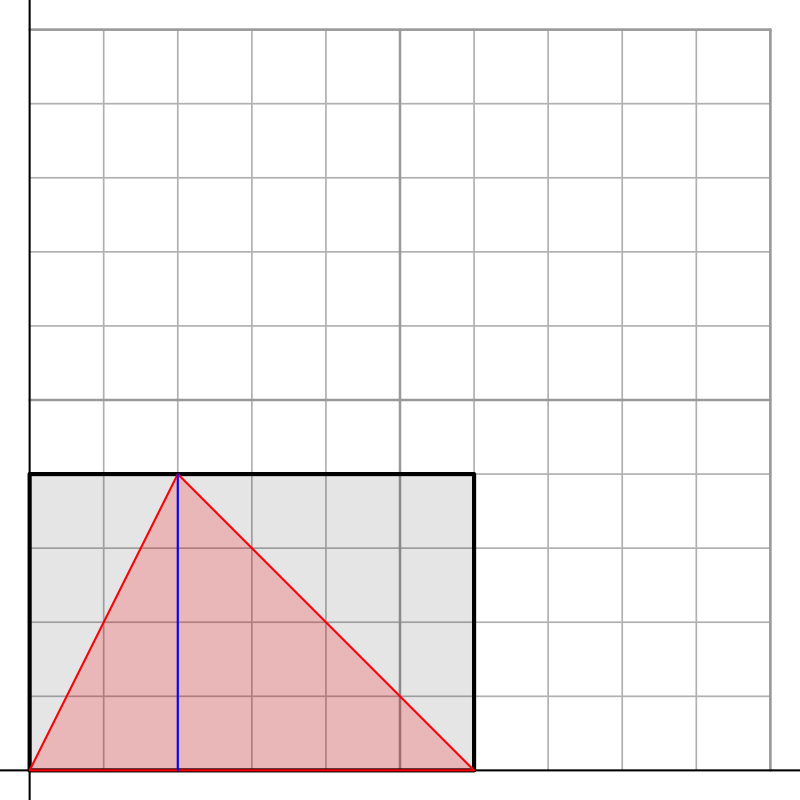

A triangle has vertices at $(0,0)$ and $(4,0)$ and $(3,4)$. Find the area (in square units).

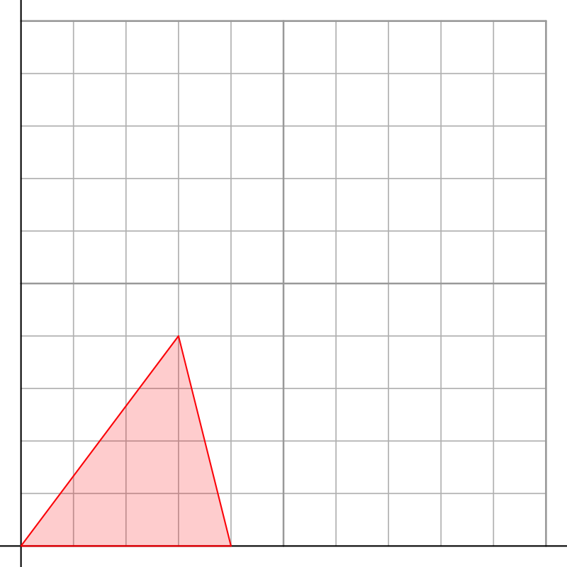

The area of a triangle is half the base times the height.

$$A=\frac{4\cdot 4}{2}$$

You should be able to see it is half the area of the surrounding rectangle...

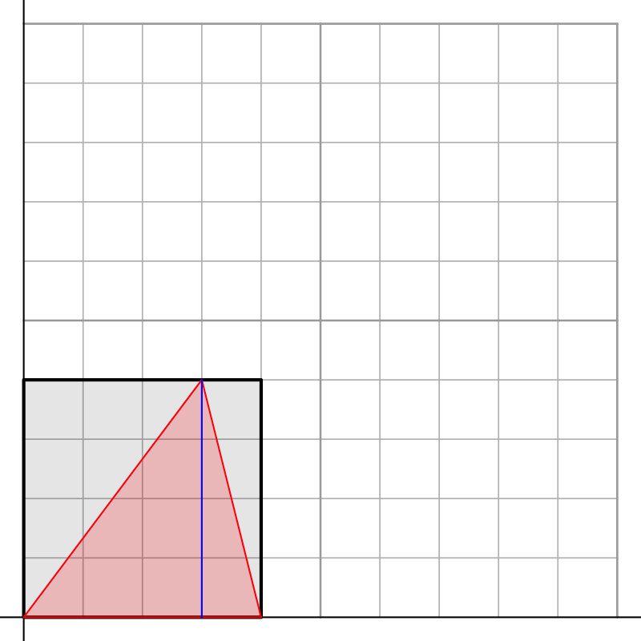

A triangle has vertices at $(0,0)$ and $(7,0)$ and $(6,5)$. Find the area (in square units).

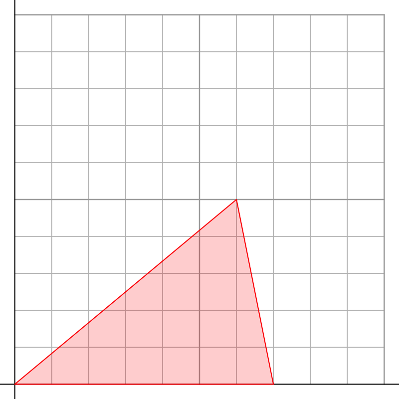

The area of a triangle is half the base times the height.